# RLDM_Report

Larissa Weyler

2024-06-14

```r
setwd("~/University/Master Cognitive Neuroscience/Reinforcement Learning and Decision-Making -  Computational and Neural Mechanisms/Report/Code")

library(ggplot2)
library(tidyverse)
library(gridExtra)
source("helper_functions.r")
options(scipen = 999) # no scientific notation

rawdata <- read.csv("dataset13.csv", sep = ",")

# colors for the plots
color1 <- "maroon4"
color2 <- "paleturquoise4"
mycolors <- c(color1, color2)
```

## Raw data exploration

### Quick overview

```r
skimr::skim(rawdata)
```

Data summary

| Name | rawdata |
| --- | --- |
| Number of rows | 9600 |
| Number of columns | 4 |
| _______________________ |  |
| Column type frequency: |  |
| numeric | 4 |
| ________________________ |  |
| Group variables | None |

**Variable type: numeric**

| skim_variable | n_missing | complete_rate | mean | sd | p0 | p25 | p50 | p75 | p100 | hist |
| --- | --- | --- | --- | --- | --- | --- | --- | --- | --- | --- |
| ID | 0 | 1 | 6.50 | 3.45 | 1.0 | 3.75 | 6.50 | 9.25 | 12.0 | ▇▅▅▅▇ |
| condition | 0 | 1 | 1.50 | 0.50 | 1.0 | 1.00 | 1.50 | 2.00 | 2.0 | ▇▁▁▁▇ |
| correct | 0 | 1 | 0.85 | 0.36 | 0.0 | 1.00 | 1.00 | 1.00 | 1.0 | ▂▁▁▁▇ |
| rt | 0 | 1 | 670.49 | 2230.91 | 325.7 | 493.77 | 602.55 | 732.29 | 217104.5 | ▇▁▁▁▁ |

```r
summary(rawdata)
```

```
##        ID          condition      correct             rt
##  Min.   : 1.00   Min.   :1.0   Min.   :0.0000   Min.   :   325.7
##  1st Qu.: 3.75   1st Qu.:1.0   1st Qu.:1.0000   1st Qu.:   493.8
##  Median : 6.50   Median :1.5   Median :1.0000   Median :   602.5
##  Mean   : 6.50   Mean   :1.5   Mean   :0.8491   Mean   :   670.5
##  3rd Qu.: 9.25   3rd Qu.:2.0   3rd Qu.:1.0000   3rd Qu.:   732.3
##  Max.   :12.00   Max.   :2.0   Max.   :1.0000   Max.   :217104.5
```

### Sample size

```r
N <- length(unique(rawdata$ID))
N
```

```
## [1] 12
```

### Histogram of overall RT distribution

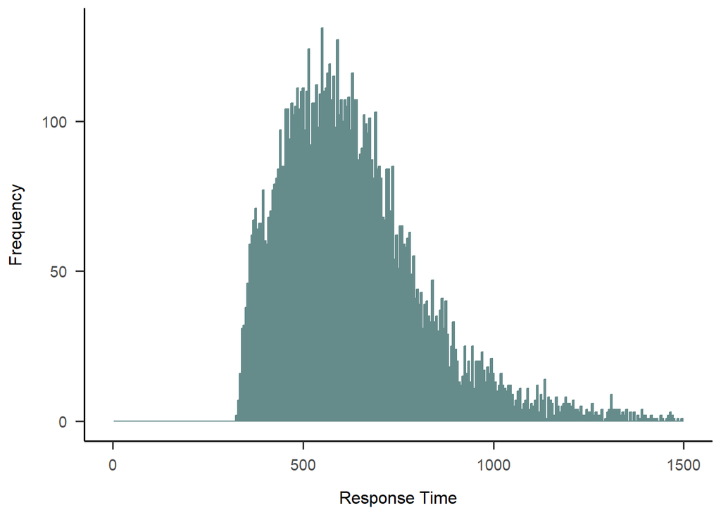

```r
ggplot(rawdata, aes(x = rt)) +
  geom_histogram(binwidth = 5, fill = color2, color = color2) +
  papaja::theme_apa() +
  labs(x = "Response Time",
       y = "Frequency") +
  xlim(c(0,1500))
```

## Outliers

### Outlier removal

```r
dataNO <- subset(rawdata,
                 rawdata$rt > (quantile(rawdata$rt, 0.25) - 1.5 * IQR(rawdata$rt))
                 & rawdata$rt < (quantile(rawdata$rt, 0.75) + 1.5 * IQR(rawdata$rt)))
```

### Outlier inspection

```r
outliers <- anti_join(rawdata, dataNO)
# overview
skimr::skim(outliers)
```

Data summary

| Name | outliers |
| --- | --- |
| Number of rows | 375 |
| Number of columns | 4 |
| _______________________ |  |
| Column type frequency: |  |
| numeric | 4 |
| ________________________ |  |
| Group variables | None |

**Variable type: numeric**

| skim_variable | n_missing | complete_rate | mean | sd | p0 | p25 | p50 | p75 | p100 | hist |
| --- | --- | --- | --- | --- | --- | --- | --- | --- | --- | --- |
| ID | 0 | 1 | 6.31 | 3.48 | 1.00 | 3.00 | 6.00 | 9.00 | 12.0 | ▇▅▆▅▇ |
| condition | 0 | 1 | 1.75 | 0.44 | 1.00 | 1.00 | 2.00 | 2.00 | 2.0 | ▃▁▁▁▇ |
| correct | 0 | 1 | 0.77 | 0.42 | 0.00 | 1.00 | 1.00 | 1.00 | 1.0 | ▂▁▁▁▇ |
| rt | 0 | 1 | 2088.88 | 11180.13 | 1090.22 | 1157.28 | 1258.58 | 1466.86 | 217104.5 | ▇▁▁▁▁ |

```r
summary(outliers)
```

```
##        ID           condition        correct            rt
##  Min.   : 1.000   Min.   :1.000   Min.   :0.000   Min.   :  1090
##  1st Qu.: 3.000   1st Qu.:1.000   1st Qu.:1.000   1st Qu.:  1157
##  Median : 6.000   Median :2.000   Median :1.000   Median :  1259
##  Mean   : 6.307   Mean   :1.747   Mean   :0.768   Mean   :  2089
##  3rd Qu.: 9.000   3rd Qu.:2.000   3rd Qu.:1.000   3rd Qu.:  1467
##  Max.   :12.000   Max.   :2.000   Max.   :1.000   Max.   :217105
```

```r
# descriptives per participant
outlierDesc <- matrix(nrow = 4, ncol = 12,
                      dimnames = list(c("N", "M rt", "MD rt", "M accuracy"), 1:12))

for (i in 1:12) {
  outlierDesc[1,i] <- sum(outliers$ID == i)
  outlierDesc[2,i] <- mean(outliers$rt[outliers$ID == i])
  outlierDesc[3,i] <- median(outliers$rt[outliers$ID == i])
  outlierDesc[4,i] <- mean(outliers$correct[outliers$ID == i])
}
outlierDesc
```

```
##                       1            2            3            4            5
## N            36.0000000   38.0000000   26.0000000   33.0000000   29.0000000
## M rt       1455.9409128 1490.3784749 1300.3821682 1569.0327943 1960.5585288
## MD rt      1231.5174287 1235.4291807 1217.4597779 1284.6138196 1258.4802631
## M accuracy    0.7222222    0.7894737    0.7307692    0.8181818    0.8275862
##                       6            7         8             9           10
## N            29.0000000   38.0000000   32.0000    26.0000000   31.0000000
## M rt       1250.9126059 1605.5681537 1314.3643 10120.3095314 1546.8375707
## MD rt      1190.3715318 1270.2581882 1237.3997  1309.5031438 1343.1782343
## M accuracy    0.7586207    0.7368421    0.6875     0.6153846    0.9032258
##                      11           12
## N            26.0000000   31.0000000
## M rt       1282.6852502 1550.2934722
## MD rt      1200.4882060 1309.5745501
## M accuracy    0.7307692    0.8709677
```

## Cleaned data inspection

```r
# overview
skimr::skim(dataNO)
```

Data summary

| Name | dataNO |
| --- | --- |
| Number of rows | 9225 |
| Number of columns | 4 |
| _______________________ |  |
| Column type frequency: |  |
| numeric | 4 |
| ________________________ |  |
| Group variables | None |

**Variable type: numeric**

| skim_variable | n_missing | complete_rate | mean | sd | p0 | p25 | p50 | p75 | p100 | hist |
| --- | --- | --- | --- | --- | --- | --- | --- | --- | --- | --- |
| ID | 0 | 1 | 6.51 | 3.45 | 1.0 | 4.00 | 7.00 | 10.00 | 12.00 | ▇▅▅▆▇ |
| condition | 0 | 1 | 1.49 | 0.50 | 1.0 | 1.00 | 1.00 | 2.00 | 2.00 | ▇▁▁▁▇ |
| correct | 0 | 1 | 0.85 | 0.35 | 0.0 | 1.00 | 1.00 | 1.00 | 1.00 | ▂▁▁▁▇ |
| rt | 0 | 1 | 612.83 | 161.42 | 325.7 | 488.97 | 593.87 | 713.79 | 1089.55 | ▅▇▆▂▁ |

```r
summary(dataNO)
```

```
##        ID           condition       correct             rt
##  Min.   : 1.000   Min.   :1.00   Min.   :0.0000   Min.   : 325.7
##  1st Qu.: 4.000   1st Qu.:1.00   1st Qu.:1.0000   1st Qu.: 489.0
##  Median : 7.000   Median :1.00   Median :1.0000   Median : 593.9
##  Mean   : 6.508   Mean   :1.49   Mean   :0.8524   Mean   : 612.8
##  3rd Qu.:10.000   3rd Qu.:2.00   3rd Qu.:1.0000   3rd Qu.: 713.8
##  Max.   :12.000   Max.   :2.00   Max.   :1.0000   Max.   :1089.6
```

```r
# descriptives per participant
dataNoDesc <- matrix(nrow = 4, ncol = 12,
                     dimnames = list(c("N", "M rt", "MD rt", "M accuracy"), 1:12))

for (i in 1:12) {
  dataNoDesc[1,i] <- sum(dataNO$ID == i)
  dataNoDesc[2,i] <- mean(dataNO$rt[dataNO$ID == i])
  dataNoDesc[3,i] <- median(dataNO$rt[dataNO$ID == i])
  dataNoDesc[4,i] <- mean(dataNO$correct[dataNO$ID == i])
}
dataNoDesc
```

```
##                      1           2           3           4           5
## N          764.0000000 762.0000000 774.0000000 767.0000000 771.0000000
## M rt       611.2135682 605.2133874 623.1877421 608.4431545 612.9221308
## MD rt      591.2154341 583.3580433 606.7147658 590.1263983 590.9818274
## M accuracy   0.8429319   0.8687664   0.8643411   0.8474576   0.8560311
##                      6           7           8           9          10
## N          771.0000000 762.0000000 768.0000000 774.0000000 769.0000000
## M rt       616.8082063 616.5006765 613.5793017 611.7486947 621.2088737
## MD rt      592.7699539 597.5054846 594.0063780 597.2620260 611.0536794
## M accuracy   0.8677043   0.8215223   0.8411458   0.8320413   0.8491547
##                     11          12
## N          774.0000000 769.0000000
## M rt       614.8993577 598.1144511
## MD rt      589.0037335 581.4576903
## M accuracy   0.8514212   0.8855657
```

```r
# descriptives per condition x correctness
conditions <- list(
  list(name = "correct_0", filter = quo(correct == 0)),
  list(name = "correct_1", filter = quo(correct == 1)),
  list(name = "condition_1", filter = quo(condition == 1)),
  list(name = "condition_2", filter = quo(condition == 2)),
  list(name = "condition_1_correct_0", filter = quo(condition == 1
                                                    & correct == 0)),
  list(name = "condition_1_correct_1", filter = quo(condition == 1
                                                    & correct == 1)),
  list(name = "condition_2_correct_0", filter = quo(condition == 2
                                                    & correct == 0)),
  list(name = "condition_2_correct_1", filter = quo(condition == 2
                                                    & correct == 1))
)

condSummary <- list()
for (cond in conditions) {
  filtered_data <- dataNO %>% filter(!!cond$filter)
  condSummary[[cond$name]] <- summary(filtered_data)
}
condSummary
```

```
## $correct_0
##        ID           condition       correct        rt
##  Min.   : 1.000   Min.   :1.00   Min.   :0   Min.   : 343.3
##  1st Qu.: 4.000   1st Qu.:1.00   1st Qu.:0   1st Qu.: 473.0
##  Median : 7.000   Median :1.00   Median :0   Median : 600.1
##  Mean   : 6.497   Mean   :1.38   Mean   :0   Mean   : 614.3
##  3rd Qu.: 9.000   3rd Qu.:2.00   3rd Qu.:0   3rd Qu.: 723.0
##  Max.   :12.000   Max.   :2.00   Max.   :0   Max.   :1089.1
##
## $correct_1
##        ID          condition        correct        rt
##  Min.   : 1.00   Min.   :1.000   Min.   :1   Min.   : 325.7
##  1st Qu.: 3.00   1st Qu.:1.000   1st Qu.:1   1st Qu.: 491.4
##  Median : 6.00   Median :2.000   Median :1   Median : 593.2
##  Mean   : 6.51   Mean   :1.509   Mean   :1   Mean   : 612.6
##  3rd Qu.:10.00   3rd Qu.:2.000   3rd Qu.:1   3rd Qu.: 712.2
##  Max.   :12.00   Max.   :2.000   Max.   :1   Max.   :1089.6
##
## $condition_1
##        ID           condition    correct             rt
##  Min.   : 1.000   Min.   :1   Min.   :0.0000   Min.   : 325.7
##  1st Qu.: 4.000   1st Qu.:1   1st Qu.:1.0000   1st Qu.: 433.4
##  Median : 6.000   Median :1   Median :1.0000   Median : 521.5
##  Mean   : 6.507   Mean   :1   Mean   :0.8206   Mean   : 548.1
##  3rd Qu.:10.000   3rd Qu.:1   3rd Qu.:1.0000   3rd Qu.: 635.3
##  Max.   :12.000   Max.   :1   Max.   :1.0000   Max.   :1088.6
##
## $condition_2
##        ID           condition    correct             rt
##  Min.   : 1.000   Min.   :2   Min.   :0.0000   Min.   : 396.4
##  1st Qu.: 4.000   1st Qu.:2   1st Qu.:1.0000   1st Qu.: 565.8
##  Median : 7.000   Median :2   Median :1.0000   Median : 661.1
##  Mean   : 6.509   Mean   :2   Mean   :0.8854   Mean   : 680.2
##  3rd Qu.:10.000   3rd Qu.:2   3rd Qu.:1.0000   3rd Qu.: 772.9
##  Max.   :12.000   Max.   :2   Max.   :1.0000   Max.   :1089.6
##
## $condition_1_correct_0
##        ID           condition    correct        rt
##  Min.   : 1.000   Min.   :1   Min.   :0   Min.   : 343.3
##  1st Qu.: 4.000   1st Qu.:1   1st Qu.:0   1st Qu.: 434.2
```

[output cut: 16 more lines]

```
##  Min.   : 1.000   Min.   :2   Min.   :0   Min.   : 446.2
##  1st Qu.: 3.250   1st Qu.:2   1st Qu.:0   1st Qu.: 624.6
##  Median : 7.000   Median :2   Median :0   Median : 709.3
##  Mean   : 6.483   Mean   :2   Mean   :0   Mean   : 727.8
##  3rd Qu.: 9.000   3rd Qu.:2   3rd Qu.:0   3rd Qu.: 817.9
##  Max.   :12.000   Max.   :2   Max.   :0   Max.   :1089.1
##
## $condition_2_correct_1
##        ID           condition    correct        rt
##  Min.   : 1.000   Min.   :2   Min.   :1   Min.   : 396.4
##  1st Qu.: 4.000   1st Qu.:2   1st Qu.:1   1st Qu.: 557.9
##  Median : 6.500   Median :2   Median :1   Median : 654.0
##  Mean   : 6.512   Mean   :2   Mean   :1   Mean   : 674.1
##  3rd Qu.:10.000   3rd Qu.:2   3rd Qu.:1   3rd Qu.: 765.7
##  Max.   :12.000   Max.   :2   Max.   :1   Max.   :1089.6
```

## RT and accuracy differences between conditions

### Histograms of RTs by condition/correctness

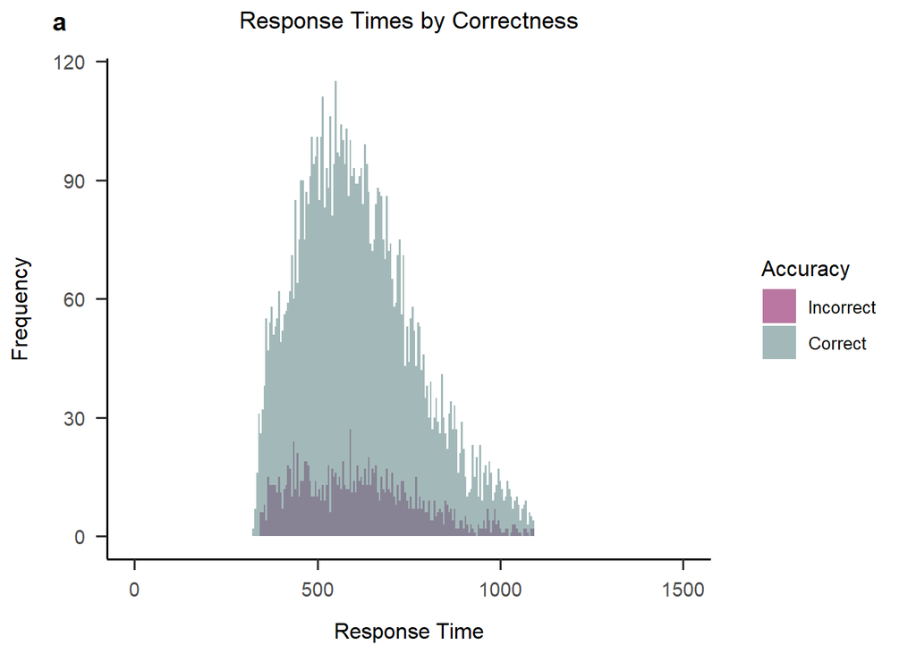

```r
# histogram for RTs of correct/incorrect responses
histCorrect <- ggplot(dataNO, aes(x = rt, group = factor(correct),
                                  fill = factor(correct))) +
  geom_histogram(binwidth = 5, alpha = .6, position = "identity") +
  papaja::theme_apa() +
  labs(title = "Response Times by Correctness",
       x = "Response Time",
       y = "Frequency",
       fill = "Accuracy") +
  scale_fill_manual(values = mycolors,
                    labels = c("Incorrect", "Correct")) +
  xlim(c(0,1500)) +
  annotate("text", x = 50, y = Inf, label = "a", size = 5,
           fontface = "bold", vjust = -1.5, hjust = 7) +
  coord_cartesian(clip = "off")
histCorrect
```

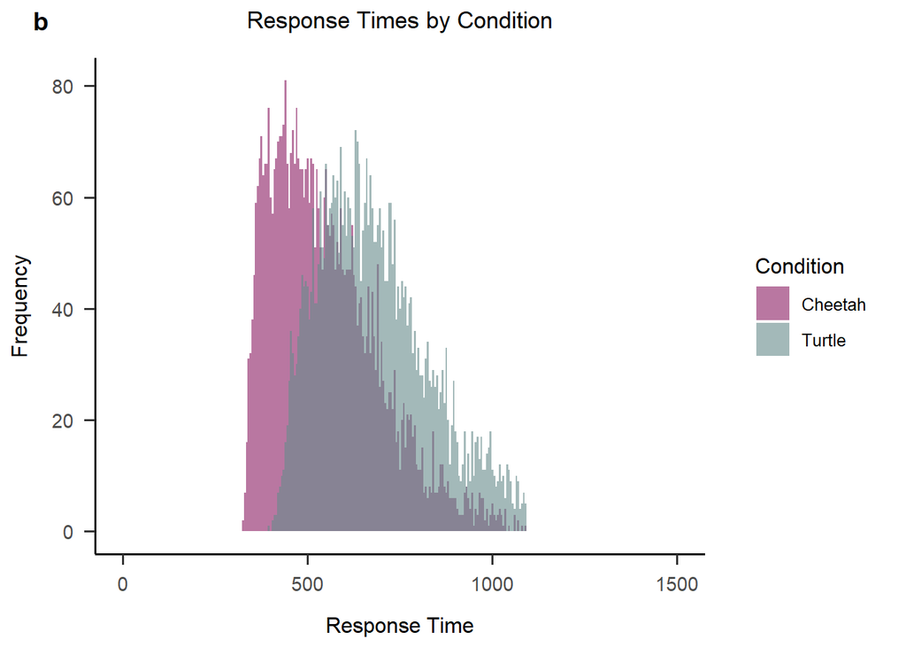

```r
# histogram for RTs of the responsees of each condition
histCond <- ggplot(dataNO, aes(x = rt, group = factor(condition),
                               fill = factor(condition)) )+
  geom_histogram(binwidth = 5, alpha = .6, position = "identity") +
  papaja::theme_apa() +
  labs(title = "Response Times by Condition",
       x = "Response Time",
       y = "Frequency",
       fill = "Condition") +
  scale_fill_manual(values = mycolors,
                    labels = c("Cheetah", "Turtle")) +
  xlim(c(0,1500)) +
  annotate("text", x = 50, y = Inf, label = "b", size = 5,
           fontface = "bold", vjust = -1.5, hjust = 7)+
  coord_cartesian(clip = "off")
histCond
```

```r
# if to be arrange next to each other (positioning of a/b labels needs to be adjusted then):
# grid.arrange(histCorrect, histCond, ncol = 2)
```

### Plots of the accuracy by condition

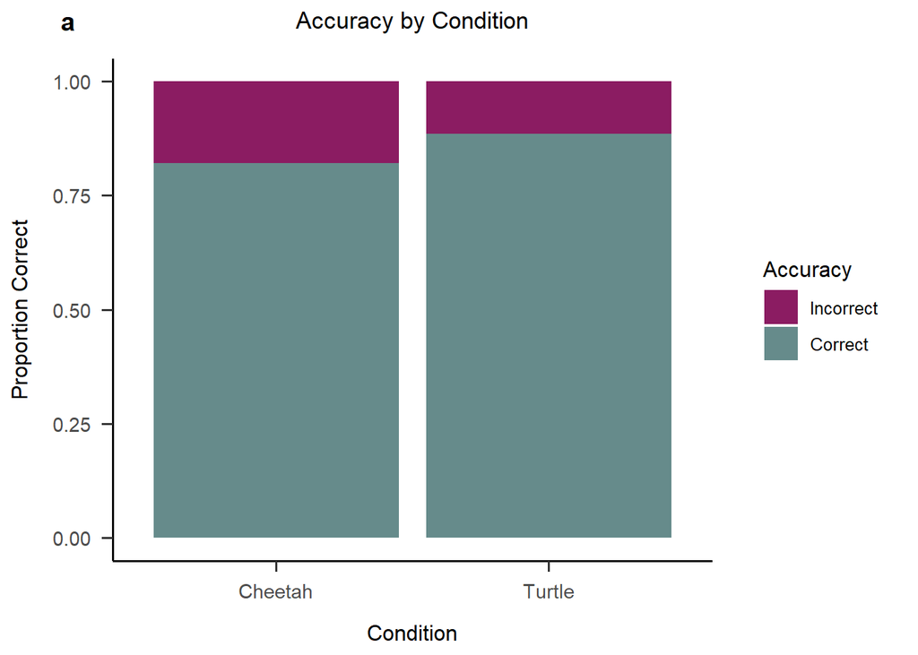

```r
# barplot of accuracy by condition
barAccuracy <- ggplot(dataNO, aes(x = factor(condition), fill = factor(correct))) +
  geom_bar(position = "fill") +
  papaja::theme_apa() +
  labs(title = "Accuracy by Condition",
       x = "Condition",
       y = "Proportion Correct",
       fill = "Accuracy") +
  scale_x_discrete(labels = c("1" = "Cheetah", "2" = "Turtle")) +
  scale_fill_manual(values = mycolors,
                    labels = c("Incorrect", "Correct")) +
  annotate("text", x = 1, y = Inf, label = "a", size = 5,
           fontface = "bold", vjust = -1.5, hjust = 15)+
  coord_cartesian(xlim = c(1,2), clip = "off")
barAccuracy
```

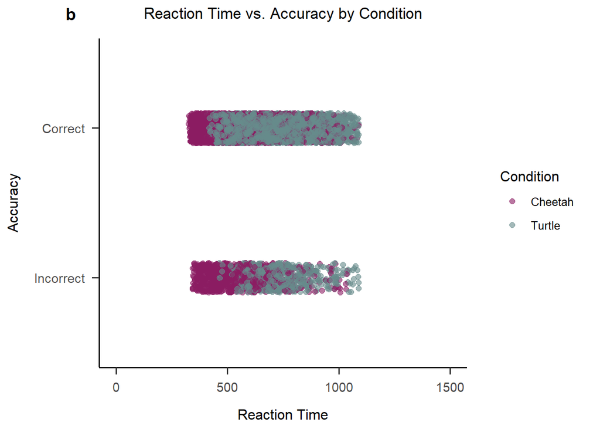

```r
# dotplot of RT vs accuracy
dotRT <- ggplot(dataNO, aes(x = rt, y = factor(correct), color = factor(condition))) +
  geom_point(position = position_jitter(height = 0.1), size = 2, alpha = 0.6) +
  scale_color_manual(name = "Condition", values = mycolors,
                     labels = c("Cheetah", "Turtle")) +
  papaja::theme_apa() +
  labs(x = "Reaction Time", y = "Accuracy",
       title = "Reaction Time vs. Accuracy by Condition") +
  scale_y_discrete(breaks = c(0, 1), labels = c("Incorrect", "Correct")) +
  xlim(c(0, 1500)) +
  annotate("text", x = 50, y = Inf, label = "b", size = 5, fontface = "bold",
           vjust = -1.5, hjust = 6)+
  coord_cartesian(clip = "off")
dotRT
```

```r
# if to be arrange next to each other (positioning of a/b labels needs to be adjusted then):
#grid.arrange(barAccuracy, dotRT, ncol = 2, nrow = 1, widths = c(0.7,1))
```

### T-tests

Paired t-tests to test whether the reaction times and accuracy differ between conditions. A paired Wilcoxon signed rank test would be an alternative that is similary powerful and more robust against non-normality, but due to aggregating the data normality should not be a problem.

```r
# difference of median rt between conditions
aggregatedDat <- dataNO %>%
  group_by(ID, condition) %>%
  summarize(median_rt = median(rt), mean_acc = mean(correct), .groups = 'drop')

cond1Rt <- aggregatedDat %>% filter(condition == 1) %>% pull(median_rt)
cond2Rt <- aggregatedDat %>% filter(condition == 2) %>% pull(median_rt)

t.test(cond1Rt, cond2Rt, paired = TRUE)
```

```
##
##  Paired t-test
##
## data:  cond1Rt and cond2Rt
## t = -39.056, df = 11, p-value = 0.0000000000003755
## alternative hypothesis: true mean difference is not equal to 0
## 95 percent confidence interval:
##  -146.6197 -130.9759
## sample estimates:
## mean difference
##       -138.7978
```

```r
# difference of mean accuracy between conditions
cond1Acc <- aggregatedDat %>% filter(condition == 1) %>% pull(mean_acc)
cond2Acc <- aggregatedDat %>% filter(condition == 2) %>% pull(mean_acc)

t.test(cond1Acc, cond2Acc, paired = TRUE)
```

```
##
##  Paired t-test
##
## data:  cond1Acc and cond2Acc
## t = -9.5062, df = 11, p-value = 0.000001223
## alternative hypothesis: true mean difference is not equal to 0
## 95 percent confidence interval:
##  -0.07995559 -0.04989194
## sample estimates:
## mean difference
##     -0.06492377
```

```r
# alternative: Wilcoxon
## wilcox.test(median_rt ~ condition, data = aggregatedDat, conf.int = TRUE, paired = TRUE)
## wilcox.test(mean_acc ~ condition, data = aggregatedDat, conf.int = TRUE, paired = TRUE)
```

## Model fitting

### Fitting model for each participant for each condition

```r
fitresults <- data.frame(ID = numeric(),
                          condition = numeric(),
                          s = numeric(),
                          A = numeric(),
                          ter = numeric(),
                          b = numeric(),
                          v1 = numeric())

for (participant in 1:length(unique(dataNO$ID))) {
  for (condition in 1:length(unique(dataNO$condition))) {
    fitsubresults <- fit_data(dataNO[dataNO$ID == participant
                                     & dataNO$condition == condition,])
    fitresults[nrow(fitresults) + 1,] <- c(participant, condition,
                                           unlist(fitsubresults))
  }
}

fitresults
```

|  | ID | condition | s | A | ter | b | v1 |
| --- | --- | --- | --- | --- | --- | --- | --- |
| 1 | 1 | 1 | 0.2102226 | 325.6268 | 311.0390097 | 344.5674 | 0.7200989 |
| 2 | 1 | 2 | 0.1740852 | 266.0706 | 273.4850956 | 402.5512 | 0.6909158 |
| 3 | 2 | 1 | 0.1689041 | 288.5980 | 298.6012457 | 320.5288 | 0.7226989 |
| 4 | 2 | 2 | 0.1372623 | 322.1502 | 356.1932512 | 396.3158 | 0.7307956 |
| 5 | 3 | 1 | 0.2135962 | 345.5778 | 329.4548378 | 358.0326 | 0.7827132 |
| 6 | 3 | 2 | 0.1925881 | 303.9231 | 304.7751575 | 423.1455 | 0.7117532 |
| 7 | 4 | 1 | 0.2721179 | 313.8105 | 319.8961061 | 331.3865 | 0.7633145 |
| 8 | 4 | 2 | 0.2022639 | 293.1188 | 346.3928647 | 381.9415 | 0.7276319 |
| 9 | 5 | 1 | 0.2328482 | 333.3876 | 338.9879481 | 335.9998 | 0.7687905 |
| 10 | 5 | 2 | 0.1816300 | 243.5593 | 234.2130025 | 418.4254 | 0.6908694 |

[output cut: 14 more lines]

**Parameters:**

`A` = *upper limit of starting point* = This reflects the starting point of the evidence accumulation process. It reflects bias or expectations for one choice.

`ter` = *non-decision time* = This reflects the time necessary for processes that are not related to evidence integration. For example, the time it takes for activation of the motor cortex to result in the hand pressing the response button, or the time it takes for visual information to get from the stimulus to the visual cortex.

`b` = *threshold* = The distance from 0 to the threshold. It reflects cautiousness: lower thresholds lead to faster responses but a higher error rate.

`v1` = *drift rate* = The quality of the evidence or difficulty of the problem. Higher drift rates lead to faster and more accurate responses.

### Parameter comparison

Via paired Wilcoxon signed rank test because the parameters are not normally distributed.

```r
parameters <- c("s", "A", "ter", "b", "v1")
paracomparison <- data.frame(Parameter = character(), tstatistic = numeric(),
                             pvalue = numeric(), stringsAsFactors = FALSE)

for (para in parameters) {
  tresult <- wilcox.test(fitresults[fitresults$condition == 1, para],
                         fitresults[fitresults$condition == 2, para],
                         paired = TRUE)
  paracomparison <- rbind(paracomparison,
                          c(para, tresult$statistic, tresult$p.value))
}
colnames(paracomparison) <- c("parameter", "tstatistic", "pvalue")
paracomparison
```

| parameter | tstatistic | pvalue |
| --- | --- | --- |
| s | 78 | 0.00048828125 |
| A | 61 | 0.0922851562500001 |
| ter | 62 | 0.0771484375000001 |
| b | 0 | 0.00048828125 |
| v1 | 70 | 0.01220703125 |

### Descriptives of parameters by condition

```r
results1 <- fitresults %>%
  filter(condition == 1)
skimr::skim(results1)
```

Data summary

| Name | results1 |
| --- | --- |
| Number of rows | 12 |
| Number of columns | 7 |
| _______________________ |  |
| Column type frequency: |  |
| numeric | 7 |
| ________________________ |  |
| Group variables | None |

**Variable type: numeric**

| skim_variable | n_missing | complete_rate | mean | sd | p0 | p25 | p50 | p75 | p100 | hist |
| --- | --- | --- | --- | --- | --- | --- | --- | --- | --- | --- |
| ID | 0 | 1 | 6.50 | 3.61 | 1.00 | 3.75 | 6.50 | 9.25 | 12.00 | ▇▅▅▅▇ |
| condition | 0 | 1 | 1.00 | 0.00 | 1.00 | 1.00 | 1.00 | 1.00 | 1.00 | ▁▁▇▁▁ |
| s | 0 | 1 | 0.23 | 0.03 | 0.17 | 0.21 | 0.24 | 0.26 | 0.27 | ▃▁▃▇▇ |
| A | 0 | 1 | 308.52 | 22.98 | 263.59 | 291.73 | 313.34 | 319.27 | 345.58 | ▂▅▂▇▃ |
| ter | 0 | 1 | 318.03 | 30.02 | 254.19 | 297.65 | 324.68 | 341.05 | 353.56 | ▂▂▅▃▇ |
| b | 0 | 1 | 329.78 | 13.97 | 312.88 | 319.65 | 328.07 | 338.14 | 358.03 | ▇▂▅▃▂ |
| v1 | 0 | 1 | 0.75 | 0.04 | 0.68 | 0.72 | 0.76 | 0.77 | 0.82 | ▅▇▇▇▂ |

```r
results2 <- fitresults %>%
  filter(condition == 2)
skimr::skim(results2)
```

Data summary

| Name | results2 |
| --- | --- |
| Number of rows | 12 |
| Number of columns | 7 |
| _______________________ |  |
| Column type frequency: |  |
| numeric | 7 |
| ________________________ |  |
| Group variables | None |

**Variable type: numeric**

| skim_variable | n_missing | complete_rate | mean | sd | p0 | p25 | p50 | p75 | p100 | hist |
| --- | --- | --- | --- | --- | --- | --- | --- | --- | --- | --- |
| ID | 0 | 1 | 6.50 | 3.61 | 1.00 | 3.75 | 6.50 | 9.25 | 12.00 | ▇▅▅▅▇ |
| condition | 0 | 1 | 2.00 | 0.00 | 2.00 | 2.00 | 2.00 | 2.00 | 2.00 | ▁▁▇▁▁ |
| s | 0 | 1 | 0.16 | 0.03 | 0.10 | 0.15 | 0.16 | 0.18 | 0.20 | ▃▂▆▇▃ |
| A | 0 | 1 | 275.71 | 41.15 | 202.54 | 242.92 | 290.50 | 306.72 | 322.15 | ▃▃▂▃▇ |
| ter | 0 | 1 | 234.56 | 117.66 | 0.48 | 198.82 | 272.74 | 313.56 | 356.19 | ▃▂▁▆▇ |
| b | 0 | 1 | 437.31 | 42.32 | 381.94 | 410.69 | 424.45 | 467.56 | 516.22 | ▅▇▂▂▃ |
| v1 | 0 | 1 | 0.69 | 0.04 | 0.60 | 0.67 | 0.70 | 0.72 | 0.73 | ▂▁▁▂▇ |

## Parameter plots

### Boxplots of all parameters

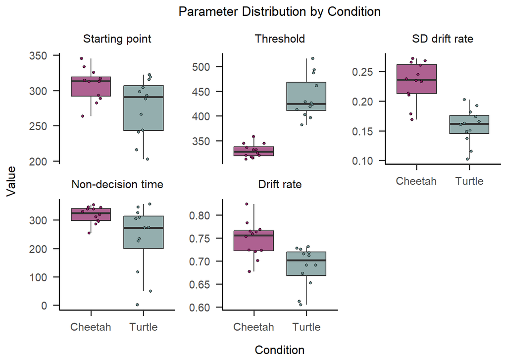

```r
fitresults_long <- fitresults %>%
  pivot_longer(cols = c(s, A, ter, b, v1),
               names_to = "parameter", values_to = "value")

ggplot(fitresults_long,
       aes(x = factor(condition), y = value, fill = factor(condition))) +
  geom_boxplot(outlier.shape = NA, alpha = 0.7) +
  geom_jitter(shape = 21, size = 1, position = position_jitter(0.2)) +
  scale_x_discrete(labels = c("Cheetah", "Turtle")) +
  facet_wrap(~ parameter, scales = "free_y",
             labeller = as_labeller(c("s" = "SD drift rate",
                                      "A" = "Starting point",
                                      "ter" = "Non-decision time",
                                      "b" = "Threshold",
                                      "v1" = "Drift rate"))) +
  scale_fill_manual(values = mycolors) +
  papaja::theme_apa() +
  theme(legend.position = "none") +
  labs(x = "Condition", y = "Value", title = "Parameter Distribution by Condition")
```

### Slope + boxplots for significant parameters

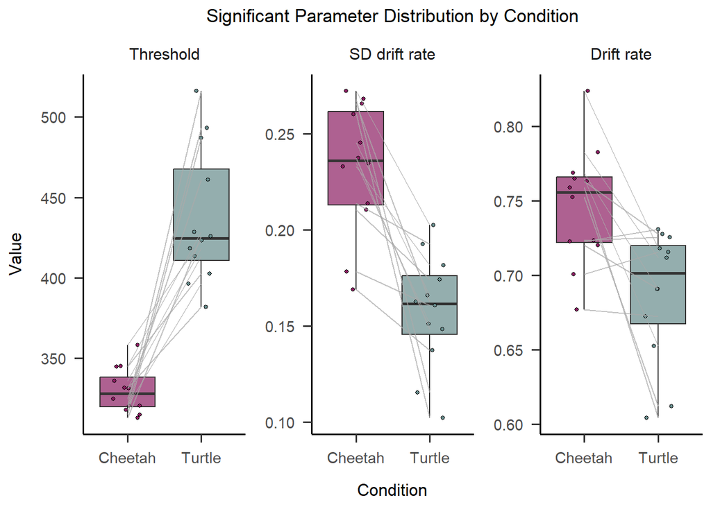

```r
# filter for significant parameters
significant_parameters <- fitresults_long %>%
  filter(parameter %in% c("s", "b", "v1"))

# plot
ggplot(significant_parameters,
       aes(x = factor(condition), y = value, fill = factor(condition))) +
  geom_boxplot(outlier.shape = NA, alpha = 0.7) +
  geom_jitter(shape = 21, size = 1, position = position_jitter(0.2)) +
  geom_line(aes(group = ID), color = "darkgrey", alpha = 0.7) +
  scale_x_discrete(labels = c("Cheetah", "Turtle")) +
  facet_wrap(~ parameter, scales = "free_y",
             labeller = as_labeller(c("s" = "SD drift rate",
                                      "A" = "Starting point",
                                      "ter" = "Non-decision time",
                                      "b" = "Threshold",
                                      "v1" = "Drift rate"))) +
  scale_fill_manual(values = mycolors) +
  papaja::theme_apa() +
  theme(legend.position = "none") +
  labs(x = "Condition", y = "Value",
       title = "Significant Parameter Distribution by Condition")
```

### Plot accumulation process

One trial of evidence accumulation using the average parameters per condition. Based on the DDM function developed during the workgroup, adapted to save current evidence of every time point of the accumulation process.

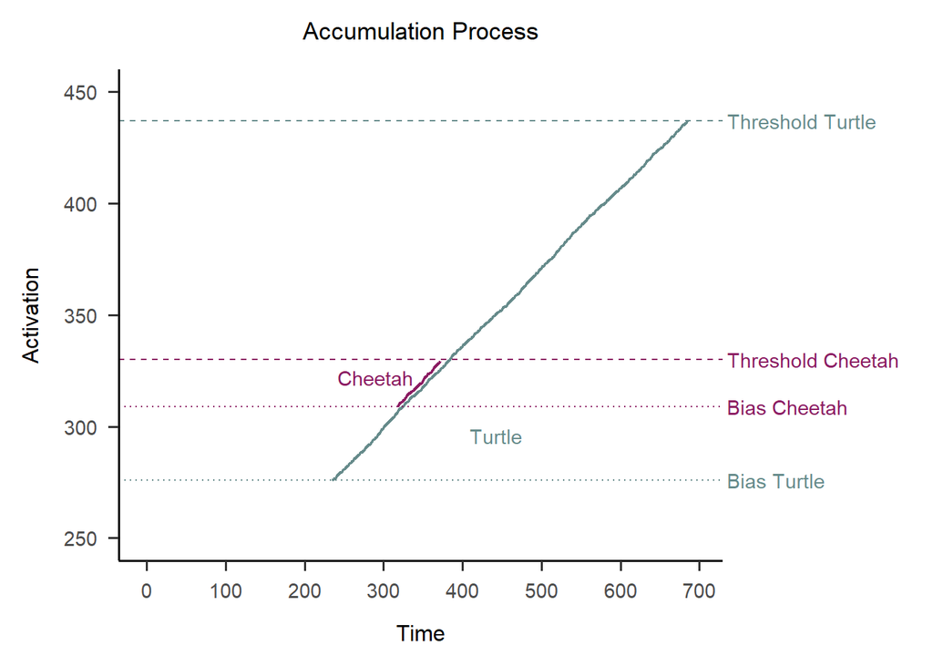

```r
# DDM function
DDM <- function(b, v1, s, ter, A) {
  act <- A
  time <- ter
  accumulation <- data.frame(time = numeric(),
                             activation = numeric(),
                             v1 = numeric(),
                             s = numeric(),
                             ter = numeric(),
                             A = numeric(),
                             condition = character())
  i <- 1
  while ((act < b) & (act > 0)) {
    accumulation <- rbind(accumulation, c(time, act, v1, s, ter, A, condition))
    drift <- rnorm(1, mean = v1, sd = s)
    act <- act + drift
    time <- time + 2
    i <- i + 1
  }
  colnames(accumulation) <- c("time", "activation", "v1", "s", "ter", "A", "condition")
  return(accumulation)
}

# fit DDM with average parameters
accumulationCheetah <- DDM(b = 330, v1 = 0.747, s = 0.232, ter = 318, A = 309)
accumulationTurtle <- DDM(b = 437, v1 = 0.688, s = 0.158, ter = 235, A =  276)

# plot evidence accumulation
ggplot() +
  geom_line(data = accumulationCheetah,
            aes(x = time, y = activation), color = color1, linewidth = 0.8) +
  geom_line(data = accumulationTurtle,
            aes(x = time, y = activation), color = color2, linewidth = 0.8) +
  geom_hline(yintercept = c(309, 276), linetype = "dotted", color = mycolors) +
  geom_hline(yintercept = c(330, 437), linetype = "dashed", color = mycolors) +
  geom_text(aes(x = max(accumulationTurtle$time) + 50, y = c(309, 330),
                label = c("Bias Cheetah", "Threshold Cheetah"),
                color = color1), hjust = 0) +
  geom_text(aes(x = max(accumulationTurtle$time) + 50, y = c(276, 437),
                label = c("Bias Turtle", "Threshold Turtle"),
                color = color2), hjust = 0) +
  geom_text(data = accumulationCheetah[1,],
            aes(x = time, y = activation, label = "Cheetah"),
            color = color1, vjust = -1.4, hjust = 0.8) +
  geom_text(data = accumulationTurtle[1,],
            aes(x = time, y = activation, label = "Turtle"),
            color = color2, vjust = -2.4, hjust = -2.6) +
  labs(title = "Accumulation Process",
       x = "Time",
       y = "Activation",
       color = "Condition") +
  scale_color_manual(name = "Condition", values = mycolors,
                     labels = c("Cheetah", "Turtle")) +
  papaja::theme_apa() +
  theme(legend.position = "none", plot.margin = unit(c(0.4, 4, 0.4, 0.4), "cm")) +
  coord_cartesian(xlim = c(0, max(accumulationTurtle$time) + 10), clip = "off") +
  scale_x_continuous(n.breaks = 6) +
  scale_y_continuous(limits = c(250,450))
```

### Correlation plot of the parameters

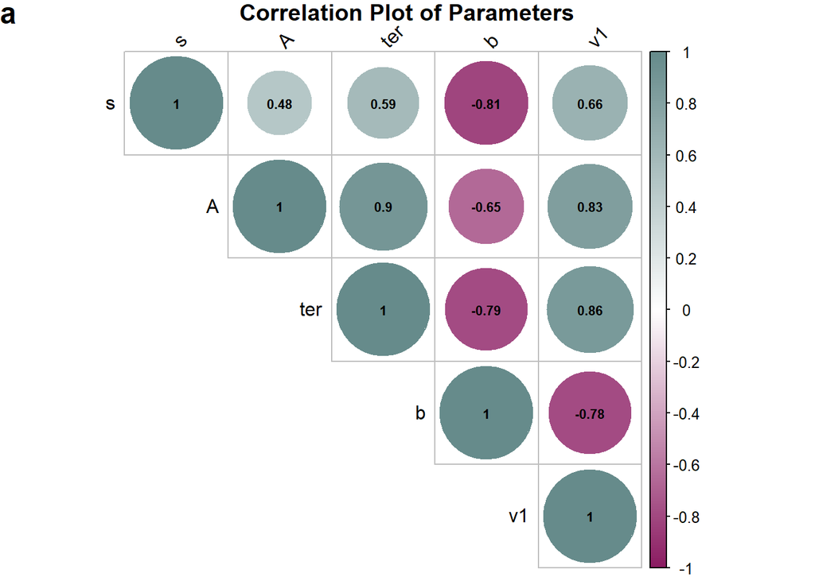

```r
# color palette for degree of correlation
color_palette <- colorRampPalette(c(color1, "white", color2))(200)

# correlation matrix
cor_matrix <- cor(fitresults[,3:7])

# plot
corrplot::corrplot(cor_matrix, method = "circle", type = "upper",
                  tl.col = "black", tl.srt = 45,
                  addCoef.col = "black", number.cex = 0.7,
                  col = color_palette,
                  title = "Correlation Plot of Parameters",
                  mar = c(0,0,1,0))
mtext("a", side = 3, line = 2.9, adj = 0, cex = 1.5, font = 2)
```

### Correlation of just v1 and b

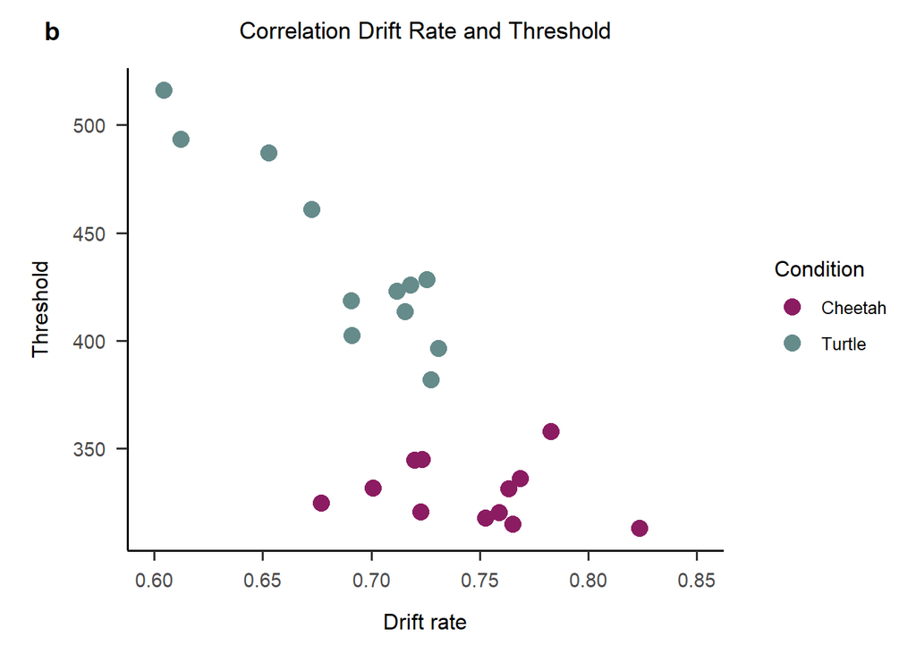

```r
ggplot(fitresults, aes(x = v1, y = b, color = factor(condition)))+
  geom_point(size = 4) +
  scale_color_manual(name = "Condition", values = mycolors,
                     labels = c("Cheetah", "Turtle")) +
  papaja::theme_apa() +
  labs(x = "Drift rate", y = "Threshold",
       title = "Correlation Drift Rate and Threshold") +
  theme(plot.margin = unit(c(0.4, 0, 0.4, 0.6), "cm")) +
  annotate("text", x = 0.6, y = Inf, label = "b", size = 5,
           fontface = "bold", vjust = -1.5, hjust = 7)+
  coord_cartesian(xlim = c(0.6,0.85), clip = "off")
```